# Applied Statistics for Life Scientists — Session 2

## What does an honest figure let you do?

What can you do with the right panel that you cannot with the left? · 2 minutes

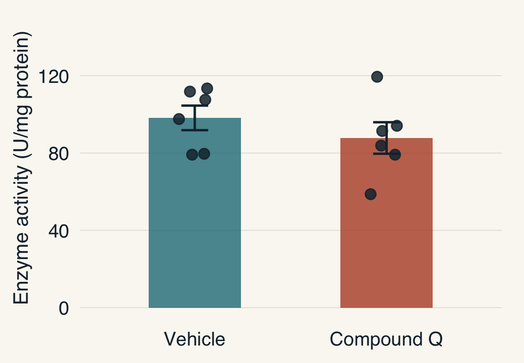

Bar chart · means ± SEM

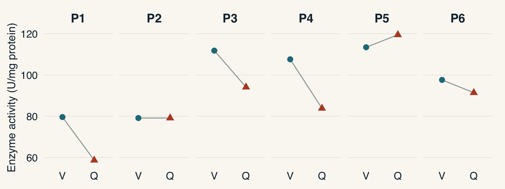

Paired plot · six preparations

Only the right panel shows which values belong together and which way each preparation moved. A good figure lets a careful reader re-examine the raw evidence.

## “Compound R suppresses inflammation”

Would you believe this conclusion? · 1 minute

LPS-stimulated macrophages were treated with vehicle or compound R (10 µM, 24 h).  
IL-6 in the supernatant was measured by ELISA.

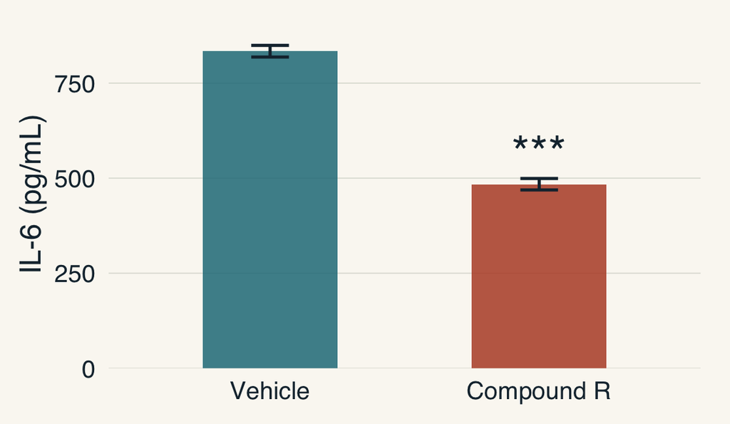

*** p < 0.001 · n = 3 · representative of independent experiments

## What do you need to know before interpreting this?

List your questions · 2 minutes

Ask the researcher.

Collect questions before offering advice.

## What was actually repeated?

Guess each layer before revealing

Four experiments, on four different days

Each day: fresh macrophages, LPS, one vehicle well and one R well

Each culture well → supernatant → three ELISA wells

The figure shows day 1 only. n = 3 counts its ELISA wells.

What is the experimental unit — and how many are there?

## “Day 4 was left out — the stimulation didn’t work.”

What would justify the exclusion? · 1 minute

What would you need to know?

Decided after the results were seen. No rule was set in advance,  
and no unstimulated control was run to check the stimulation.

Vehicle IL-6 on day 4: 501 pg/mL — the lowest, but days 1–3 ranged from 834 to 2444.  
On day 4, R did not lower IL-6.

## Look at all four experiments

Which panel shows what R did? · 2 minutes

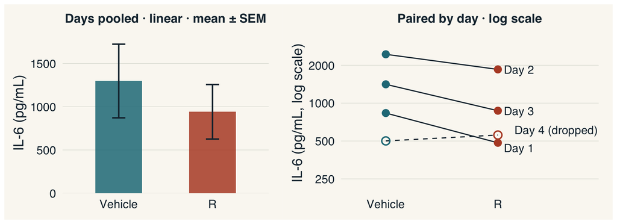

IL-6 varies five-fold between days — but within days 1–3, R was always lower.

Each point = one culture well (mean of its three ELISA wells). Dashed: day 4, dropped by the researcher.

## Analyse the experiment, not the ELISA wells

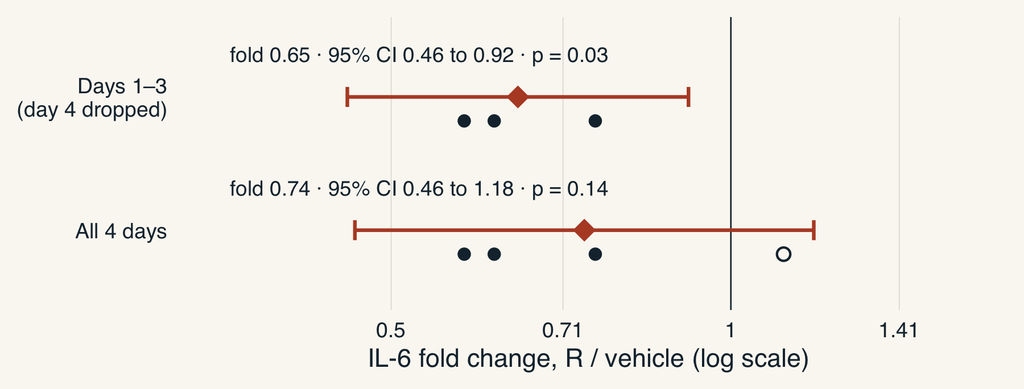

Reported: p < 0.001. Per experiment: p = 0.03 — or p = 0.14 if day 4 stays in.

One fold change per experiment, paired by day, on the log scale. The decision about day 4 matters more than the choice of test.

## IL-6, TNF and IL-1β were measured. Why report only IL-6?

Why might only IL-6 have been reported? · 1 minute

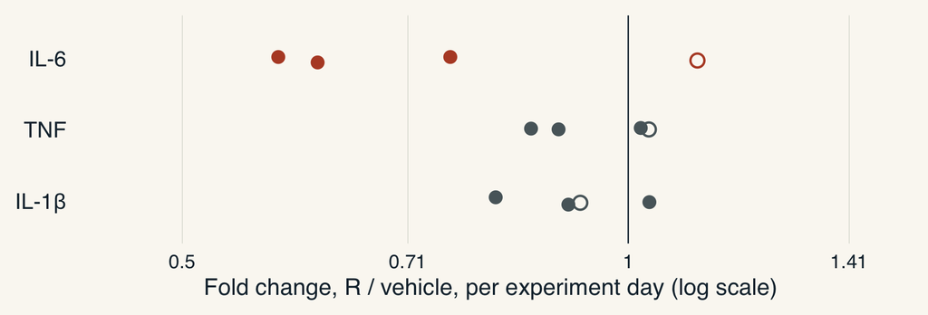

Choosing the readout after seeing the data makes IL-6 an exploratory finding.

One point per experiment day. Open circles: day 4.

## “Suppresses inflammation” — what can these data support?

Choose the strongest claim you could defend to a reviewer

R suppresses inflammation

R lowers IL-6, TNF and IL-1β

R lowered IL-6 in LPS-stimulated macrophages in 3 of 4 experiments — worth a planned repeat

R is anti-inflammatory in patients

## Done correctly, the answer is usually less exciting

Key message

Done correctly, the answer is usually  
less exciting than the first impression.

“R suppresses inflammation, p < 0.001” became “R lowered IL-6 in 3 of 4 experiments — worth a planned repeat.” That is not a failure: it is the result that will still hold next year.

## Repeat the study so it can answer the question

Pairs or small groups · 6 minutes · keywords or a sketch are enough

**Question and primary readout**  
What exactly do we want to learn? What is measured first?

**Experimental unit and N**  
What is independently repeated, and how often?

**Pairing and allocation**  
What should share a day or plate? How are wells assigned?

**QC and exclusions**  
Which rules are fixed before the results are seen?

**Analysis and report**  
Which effect, scale and interval? Which figure?

## One defensible repeat — not the only one

**Question**  
Does 10 µM R lower IL-6 in LPS-stimulated macrophages?  
IL-6 primary; TNF and IL-1β exploratory

**Unit and N**  
One culture well per condition per independent experiment  
About 7 experiments for a 30% reduction, from the variability seen here

**Pairing**  
Vehicle and R on the same day and plate; positions randomized

**QC, fixed in advance**  
Include an unstimulated well; keep an experiment only if LPS raises IL-6 ≥ 10-fold

**Analysis and report**  
Log fold change per experiment, paired; mean fold change with 95% CI; show every experiment

## What improved before any test was run?

Name your most consequential change · 1 minute

### Original report

One “representative” day shown  
n counted ELISA wells  
Day 4 dropped after seeing it  
IL-6 picked from three readouts  
Pooled bars, linear scale

### Planned repeat

Every experiment shown  
n = independent experiments  
QC rule fixed in advance  
One primary readout  
Paired log fold changes with CI

Most of the improvement happened before the statistical test.

## Plan the experiment before you pipette

Key message

Good experiments are designed before the first pipetting step — not rescued afterwards.

Question · experimental unit · N · pairing and blocking · QC rules · analysis: write them down first.

Further reading: S.E. Lazic (2016) *Experimental Design for Laboratory Biologists: Maximising Information and Improving Reproducibility.* Cambridge University Press. · D.J. Glass (2014) *Experimental Design for Biologists*, 2nd ed. Cold Spring Harbor Laboratory Press.

## “My p-value is below 0.001. Is my result real?”

Formulate your answer · 1 minute

How would you respond now?

Tell me how the experiment was done, what was independently repeated,  
what effect you wanted to estimate — and how this result was selected.

## From a biological question to a defensible claim

Design and analysis decisions surround the whole process

Question → experiment → experimental units → variation  
→ data → effect estimate → uncertainty  
→ model → inference → claim

Power: information needed for the intended effect  
Multiplicity: opportunities created by the intended claims

## Ten things to take home

Key messages

1. Report an effect with its SEM or, better, its 95% CI — not the SD.
2. A small p-value is not a large effect. Judge biological relevance from the effect and its interval.
3. p > 0.05 does not mean no effect. Absence of evidence is not evidence of absence.
4. Exploration generates hypotheses; its p-values mean little. Confirm in a new experiment.
5. Record metadata — preparation, day, tube, well — for every value.
6. Paired and blocked designs have higher power. Keep the pairing in the analysis.
7. Simple designs need fewer replicates. Every extra group or factor costs power.
8. Fluorescence, RNA, protein and cytokine levels, counts: analyse on a log scale.
9. Done correctly, the answer is usually less exciting — and more likely to hold.
10. Plan the experiment before you pipette (Lazic 2016; Glass 2014).

## Statistics cannot rescue an experiment that could not answer the question.

Design the experiment and the analysis together.